# Analysis of Total Reading Times

Henrik Singmann

01 August, 2017

```r
require(dplyr)
require(tidyr)
require(stringr)
require(ggplot2)
require(afex)
require(lattice) # for qqmath
require(gridExtra)
library(ggthemes)
```

```r
theme_set(theme_minimal())
```

# Data Preparation

For the analysis we remove 2 trials with missing data in either spillover or Consequent. Then we transform all RTs from ms to s and calculate transformed versions using either `log` or the inverse transformation. We also z-transform the continuous `Accepts` variable.

```r
drp_r <- drp_r %>%
  mutate(
    antecedent = Antecedent/1000,
    log_ant = log(antecedent),
    inv_ant = 1/antecedent,
    consequent = Consequent/1000,
    log_con = log(consequent),
    inv_con = 1/consequent,
    spillover = spillover/1000,
    log_spill = log(spillover),
    inv_spill = 1/spillover,
    acc_z = (Accepts - mean(Accepts))/sd(Accepts),
    #conf_z = (Confident- mean(Confident))/sd(Confident),
    log_acc= log(Accepts))
```

We then plot the three versions of the DVs.

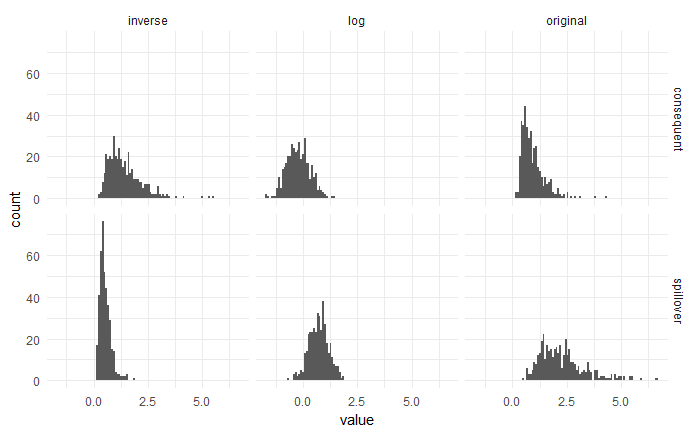

```r
dplot <- drp_r %>%
  gather("key", "value",consequent:inv_spill, spillover) %>%
  mutate(region = if_else(str_detect(key, "spill"), "spillover", "consequent"),
         type = if_else(str_detect(key, "^log"), "log",
                        if_else(str_detect(key, "^inv"), "inverse", "original")))
ggplot(data = dplot) +
  geom_histogram(mapping = aes(x = value), bins = 100) +
  facet_grid(region ~ type)
```

As can be seen, the log transformation helps quite a bit in achieving approximate normality for both consequent and spillover. However, both DVs seems to have too fat tails. For the `spillover` variable the untransformed DV may work better. For the untransformed values there are quite a few DVs above 5 seconds (consequent = 0, spillover = 0.02), above 3 seconds (consequent = 0.01, spillover = 0.2) or above 2.5 seconds (consequent = 0.02, spillover = 0.34).

# Descriptive Plots

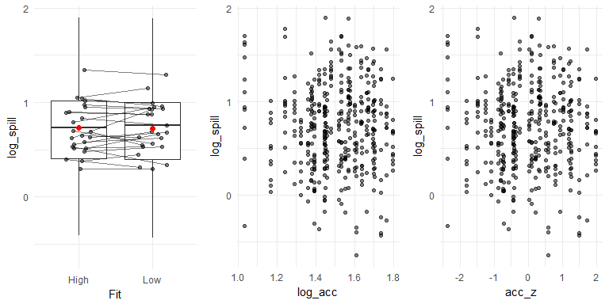

```r
drd_a2 <- drp_r %>%
  group_by(P.s, Fit) %>%
  summarise(log_spill = mean(log_spill))
drp_r$Fit2 <- jitter(as.numeric(drp_r$Fit))
drd_a2$Fit2 <- jitter(as.numeric(drd_a2$Fit))
pres_rp_a <- ggplot(data = drp_r, mapping = aes(x = Fit, y = log_spill)) +
  geom_boxplot(outlier.color =  NA) +
  geom_line(data = drd_a2, aes(x=Fit2, y=log_spill, group = P.s), alpha = 0.5) +
  geom_point(data = drd_a2, aes(x=Fit2, y=log_spill, group = P.s), alpha = 0.5) +
  stat_summary(fun.y = "mean", colour = "red", size = 2, geom = "point")
pres_rp_b <- ggplot(data = drp_r, mapping = aes(x = log_acc, y = log_spill)) +
  geom_point(alpha = 0.5)
pres_rp_c <- ggplot(data = drp_r, mapping = aes(x = acc_z, y = log_spill)) +
  geom_point(alpha = 0.5)
grid.arrange(pres_rp_a, pres_rp_b, pres_rp_c, ncol = 3)
```

# Consequent

Note that the maximal model for models including `Fit` have random slopes for `Fit` for both random effects grouping factors (i.e., participant `P.s` and `Item`). For models including the continuous fit measure `Accepts` we have by-participant random slopes for `Accepts`, but by-item random slopes for `Fit` (as `Accepts` has only two different values for each `Item`, using the binary `Fit` variable seems more reasonable.)

## With Fit (log-transformed RTs)

```r
m_fp_con_1 <- mixed(log_con ~ Fit + (Fit|P.s) + (Fit| Item), drp_r, progress = FALSE)
```

```
Contrasts set to contr.sum for the following variables: Fit, P.s, Item
```

```r
summary(m_fp_con_1)
```

```
Linear mixed model fit by REML ['merModLmerTest']
Formula: log_con ~ Fit + (Fit | P.s) + (Fit | Item)
   Data: drp_r

REML criterion at convergence: 490.3

Scaled residuals:
    Min      1Q  Median      3Q     Max
-2.7240 -0.5898 -0.0262  0.5508  3.9727

Random effects:
 Groups   Name        Variance  Std.Dev. Corr
 P.s      (Intercept) 0.0710498 0.26655
          Fit1        0.0025638 0.05063  0.90
 Item     (Intercept) 0.0615659 0.24812
          Fit1        0.0009968 0.03157  0.64
 Residual             0.1526958 0.39076
Number of obs: 406, groups:  P.s, 24; Item, 17

Fixed effects:
            Estimate Std. Error t value
(Intercept) -0.21464    0.08342  -2.573
Fit1        -0.04071    0.02330  -1.747

Correlation of Fixed Effects:
     (Intr)
Fit1 0.413
```

Although the correlations are not extreme, we try by removing them.

```r
m_fp_con_2 <- mixed(log_con ~ Fit + (Fit||P.s) + (Fit|| Item), drp_r, expand_re = TRUE, progress = FALSE)
```

```
Contrasts set to contr.sum for the following variables: Fit, P.s, Item
```

```r
summary(m_fp_con_2)
```

```
Linear mixed model fit by REML ['merModLmerTest']
Formula: log_con ~ Fit + ((1 | P.s) + (0 + re1.Fit1 | P.s)) + ((1 | Item) +
    (0 + re2.Fit1 | Item))
   Data: drp_r

REML criterion at convergence: 495

Scaled residuals:
    Min      1Q  Median      3Q     Max
-2.7634 -0.6040 -0.0435  0.5574  4.0085

Random effects:
 Groups   Name        Variance  Std.Dev.
 P.s      (Intercept) 0.0708167 0.26611
 P.s.1    re1.Fit1    0.0024137 0.04913
 Item     (Intercept) 0.0618489 0.24869
 Item.1   re2.Fit1    0.0009961 0.03156
 Residual             0.1528138 0.39091
Number of obs: 406, groups:  P.s, 24; Item, 17

Fixed effects:
            Estimate Std. Error t value
(Intercept) -0.21397    0.08346  -2.564
Fit1        -0.04060    0.02317  -1.752

Correlation of Fixed Effects:
     (Intr)
Fit1 0.001
```

This does not seem to be justified when looking at likelihood-ratio tests.

```r
anova(m_fp_con_1, m_fp_con_2)
```

```
Data: drp_r
Models:
m_fp_con_2: log_con ~ Fit + ((1 | P.s) + (0 + re1.Fit1 | P.s)) + ((1 | Item) +
m_fp_con_2:     (0 + re2.Fit1 | Item))
m_fp_con_1: log_con ~ Fit + (Fit | P.s) + (Fit | Item)
           Df    AIC    BIC  logLik deviance  Chisq Chi Df Pr(>Chisq)
m_fp_con_2  7 508.98 537.02 -247.49   494.98
m_fp_con_1  9 508.34 544.39 -245.17   490.34 4.6422      2    0.09817 .
---
Signif. codes:  0 *** 0.001 ** 0.01 * 0.05 . 0.1   1
```

However, the QQ-plot of both models shows some departure from normality for both short RTs and somewhat long RTs. One RT for participant 10 departs particularly strongly. Significant outliers (i.e., observations with absolute standardized/normalized residuals greater than the .995 quantile of the standard normal distribution) are identified by the number of the participant providing this response.

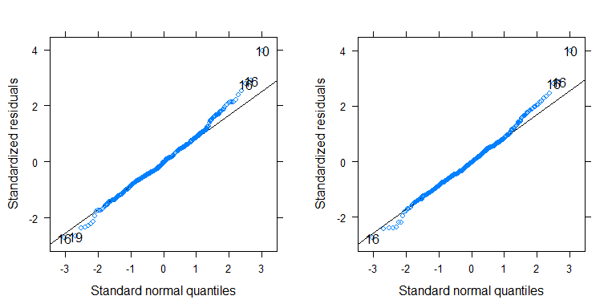

```r
qqp_m1 <- qqmath(m_fp_con_1$full_model, id = 0.01, idLabels = as.character(drp_r$P.s))
qqp_m2 <- qqmath(m_fp_con_2$full_model, id = 0.01, idLabels = as.character(drp_r$P.s))
grid.arrange(qqp_m1, qqp_m2, ncol = 2)
```

The effect of `Fit` is not significant for both models, but approaches significance.

```r
nice(m_fp_con_1)
```

```
Mixed Model Anova Table (Type 3 tests, KR-method)

Model: log_con ~ Fit + (Fit | P.s) + (Fit | Item)
Data: drp_r
  Effect       df    F p.value
1    Fit 1, 12.45 3.05     .11
---
Signif. codes:  0 *** 0.001 ** 0.01 * 0.05 + 0.1   1
```

```r
nice(m_fp_con_2)
```

```
Mixed Model Anova Table (Type 3 tests, KR-method)

Model: log_con ~ Fit + (Fit || P.s) + (Fit || Item)
Data: drp_r
  Effect       df    F p.value
1    Fit 1, 12.27 3.07     .10
---
Signif. codes:  0 *** 0.001 ** 0.01 * 0.05 + 0.1   1
```

## With Fit (untransformed RTs)

```r
m_con_u_1 <- mixed(consequent ~ Fit + (Fit|P.s) + (Fit| Item), drp_r, progress = FALSE)
```

```
Contrasts set to contr.sum for the following variables: Fit, P.s, Item
```

```r
summary(m_con_u_1)
```

```
Linear mixed model fit by REML ['merModLmerTest']
Formula: consequent ~ Fit + (Fit | P.s) + (Fit | Item)
   Data: drp_r

REML criterion at convergence: 550.3

Scaled residuals:
    Min      1Q  Median      3Q     Max
-2.0369 -0.5504 -0.1420  0.3693  7.3286

Random effects:
 Groups   Name        Variance  Std.Dev. Corr
 P.s      (Intercept) 6.252e-02 0.250045
          Fit1        1.457e-03 0.038165 1.00
 Item     (Intercept) 5.808e-02 0.241001
          Fit1        8.892e-06 0.002982 1.00
 Residual             1.826e-01 0.427274
Number of obs: 406, groups:  P.s, 24; Item, 17

Fixed effects:
            Estimate Std. Error t value
(Intercept)  0.93225    0.08045  11.589
Fit1        -0.02479    0.02263  -1.096

Correlation of Fixed Effects:
     (Intr)
Fit1 0.243
```

Due to the extreme correlations between the by-participant and by-item intercept and slopes we refit the model without the correlations.

```r
m_con_u_2 <- mixed(consequent ~ Fit + (Fit||P.s) + (Fit|| Item), drp_r,
                   progress = FALSE, expand_re = TRUE)
```

```
Contrasts set to contr.sum for the following variables: Fit, P.s, Item
```

```r
summary(m_con_u_2)
```

```
Linear mixed model fit by REML ['merModLmerTest']
Formula: consequent ~ Fit + ((1 | P.s) + (0 + re1.Fit1 | P.s)) + ((1 |
    Item) + (0 + re2.Fit1 | Item))
   Data: drp_r

REML criterion at convergence: 553.1

Scaled residuals:
    Min      1Q  Median      3Q     Max
-2.1875 -0.5820 -0.1523  0.3777  7.4069

Random effects:
 Groups   Name        Variance Std.Dev.
 P.s      (Intercept) 0.06216  0.2493
 P.s.1    re1.Fit1    0.00000  0.0000
 Item     (Intercept) 0.05830  0.2415
 Item.1   re2.Fit1    0.00000  0.0000
 Residual             0.18414  0.4291
Number of obs: 406, groups:  P.s, 24; Item, 17

Fixed effects:
            Estimate Std. Error t value
(Intercept)  0.93282    0.08046  11.594
Fit1        -0.02462    0.02133  -1.155

Correlation of Fixed Effects:
     (Intr)
Fit1 0.001
```

Now the `Fit` random slopes show no variability so we consequently refit the model without that parameter.

```r
m_con_u_3 <- mixed(consequent ~ Fit + (1|P.s) + (1| Item), drp_r, progress = FALSE)
```

```
Contrasts set to contr.sum for the following variables: Fit, P.s, Item
```

```r
summary(m_con_u_3)
```

```
Linear mixed model fit by REML ['merModLmerTest']
Formula: consequent ~ Fit + (1 | P.s) + (1 | Item)
   Data: drp_r

REML criterion at convergence: 553.1

Scaled residuals:
    Min      1Q  Median      3Q     Max
-2.1875 -0.5820 -0.1523  0.3777  7.4069

Random effects:
 Groups   Name        Variance Std.Dev.
 P.s      (Intercept) 0.06216  0.2493
 Item     (Intercept) 0.05830  0.2415
 Residual             0.18414  0.4291
Number of obs: 406, groups:  P.s, 24; Item, 17

Fixed effects:
            Estimate Std. Error t value
(Intercept)  0.93282    0.08046  11.594
Fit1        -0.02462    0.02133  -1.155

Correlation of Fixed Effects:
     (Intr)
Fit1 0.001
```

This model seems reasonable and only provides a minimally worse account than the first model.

```r
anova(m_con_u_1, m_con_u_2, m_con_u_3)
```

```
Data: drp_r
Models:
m_con_u_3: consequent ~ Fit + (1 | P.s) + (1 | Item)
m_con_u_2: consequent ~ Fit + ((1 | P.s) + (0 + re1.Fit1 | P.s)) + ((1 |
m_con_u_2:     Item) + (0 + re2.Fit1 | Item))
m_con_u_1: consequent ~ Fit + (Fit | P.s) + (Fit | Item)
          Df    AIC    BIC  logLik deviance  Chisq Chi Df Pr(>Chisq)
m_con_u_3  5 563.05 583.09 -276.53   553.05
m_con_u_2  7 567.05 595.10 -276.53   553.05 0.0000      2     1.0000
m_con_u_1  9 568.33 604.39 -275.17   550.33 2.7212      2     0.2565
```

However, the QQ-plot now shows the perhaps expected misfit for long RTs.

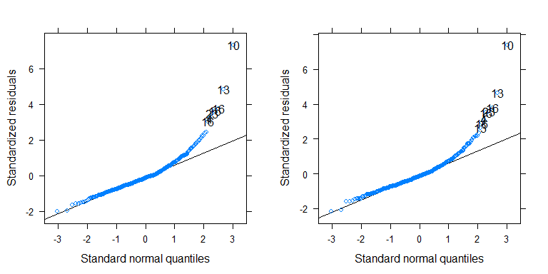

```r
qqp_m1 <- qqmath(m_con_u_1$full_model, id = 0.01, idLabels = as.character(drp_r$P.s))
qqp_m2 <- qqmath(m_con_u_3$full_model, id = 0.01, idLabels = as.character(drp_r$P.s))
grid.arrange(qqp_m1, qqp_m2, ncol = 2)
```

Again, the effect of `Fit` is not significant.

```r
nice(m_con_u_1)
nice(m_con_u_3)
```

[output not shown]

## With Fit (log-transformed RTs), Reduced Sample

We refit the logged RTs with a reduced model for which we remove one response of ID 10.

```r
outl <- (drp_r$P.s == "10" & drp_r$consequent > 4) #|
  #(drp_r$P.s == "16" & (drp_r$log_con < -1 | drp_r$log_con > 1) )
drp_r_1 <- drp_r[!outl,]
```

```r
m_fp_con_1b <- mixed(log_con ~ Fit + (Fit|P.s) + (Fit| Item), drp_r_1, progress = FALSE)
```

```
Contrasts set to contr.sum for the following variables: Fit, P.s, Item
```

```r
summary(m_fp_con_1b)
```

```
Linear mixed model fit by REML ['merModLmerTest']
Formula: log_con ~ Fit + (Fit | P.s) + (Fit | Item)
   Data: drp_r_1

REML criterion at convergence: 472

Scaled residuals:
     Min       1Q   Median       3Q      Max
-2.80154 -0.60428 -0.04057  0.58472  2.95298

Random effects:
 Groups   Name        Variance Std.Dev. Corr
 P.s      (Intercept) 0.070048 0.26466
          Fit1        0.002931 0.05414  0.81
 Item     (Intercept) 0.062945 0.25089
          Fit1        0.001399 0.03741  0.59
 Residual             0.144865 0.38061
Number of obs: 405, groups:  P.s, 24; Item, 17

Fixed effects:
            Estimate Std. Error t value
(Intercept) -0.21887    0.08354  -2.620
Fit1        -0.04478    0.02374  -1.887

Correlation of Fixed Effects:
     (Intr)
Fit1 0.409
```

Although the correlations are not extreme, we try by removing them.

```r
m_fp_con_2b <- mixed(log_con ~ Fit + (Fit||P.s) + (Fit|| Item), drp_r_1, progress = FALSE, expand_re = TRUE)
```

```
Contrasts set to contr.sum for the following variables: Fit, P.s, Item
```

```r
summary(m_fp_con_2b)
```

```
Linear mixed model fit by REML ['merModLmerTest']
Formula: log_con ~ Fit + ((1 | P.s) + (0 + re1.Fit1 | P.s)) + ((1 | Item) +
    (0 + re2.Fit1 | Item))
   Data: drp_r_1

REML criterion at convergence: 476.5

Scaled residuals:
     Min       1Q   Median       3Q      Max
-2.83286 -0.58957 -0.05224  0.56426  2.94141

Random effects:
 Groups   Name        Variance Std.Dev.
 P.s      (Intercept) 0.069809 0.26421
 P.s.1    re1.Fit1    0.002806 0.05297
 Item     (Intercept) 0.063124 0.25125
 Item.1   re2.Fit1    0.001404 0.03747
 Residual             0.144968 0.38075
Number of obs: 405, groups:  P.s, 24; Item, 17

Fixed effects:
            Estimate Std. Error t value
(Intercept) -0.21826    0.08355  -2.612
Fit1        -0.04467    0.02364  -1.890

Correlation of Fixed Effects:
     (Intr)
Fit1 0.001
```

This does not seem to be justified when looking at likelihood-ratio tests.

```r
anova(m_fp_con_1b, m_fp_con_2b)
```

```
Data: drp_r_1
Models:
m_fp_con_2b: log_con ~ Fit + ((1 | P.s) + (0 + re1.Fit1 | P.s)) + ((1 | Item) +
m_fp_con_2b:     (0 + re2.Fit1 | Item))
m_fp_con_1b: log_con ~ Fit + (Fit | P.s) + (Fit | Item)
            Df    AIC    BIC  logLik deviance  Chisq Chi Df Pr(>Chisq)
m_fp_con_2b  7 490.49 518.52 -238.25   476.49
m_fp_con_1b  9 489.96 525.99 -235.98   471.96 4.5334      2     0.1037
```

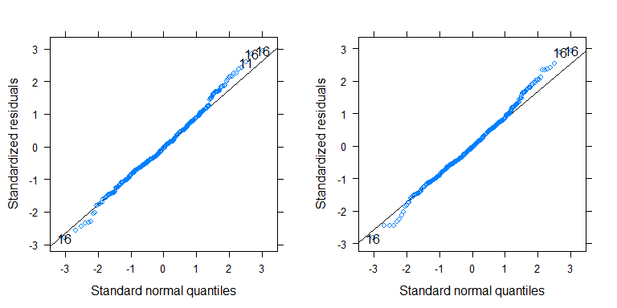

```r
qqp_m1 <- qqmath(m_fp_con_1b$full_model, id = 0.01, idLabels = as.character(drp_r_1$P.s))
qqp_m2 <- qqmath(m_fp_con_2b$full_model, id = 0.01, idLabels = as.character(drp_r_1$P.s))
grid.arrange(qqp_m1, qqp_m2, ncol = 2)
```

The effect of `Fit` is not significant for both models, but approaches significance.

```r
nice(m_fp_con_1b)
```

```
Mixed Model Anova Table (Type 3 tests, KR-method)

Model: log_con ~ Fit + (Fit | P.s) + (Fit | Item)
Data: drp_r_1
  Effect       df      F p.value
1    Fit 1, 13.33 3.56 +     .08
---
Signif. codes:  0 *** 0.001 ** 0.01 * 0.05 + 0.1   1
```

```r
nice(m_fp_con_2b)
```

```
Mixed Model Anova Table (Type 3 tests, KR-method)

Model: log_con ~ Fit + (Fit || P.s) + (Fit || Item)
Data: drp_r_1
  Effect       df      F p.value
1    Fit 1, 13.18 3.57 +     .08
---
Signif. codes:  0 *** 0.001 ** 0.01 * 0.05 + 0.1   1
```

## With Accepts (log-transformed RT and Accepts)

```r
m_fp_con_11 <- mixed(log_con ~ log_acc + (log_acc|P.s) + (Fit| Item), drp_r, progress = FALSE)
```

```
Contrasts set to contr.sum for the following variables: P.s, Fit, Item
Numerical variables NOT centered on 0 (i.e., interpretation of all main effects might be difficult if in interactions): log_acc
```

```r
summary(m_fp_con_11)
```

```
Linear mixed model fit by REML ['merModLmerTest']
Formula: log_con ~ log_acc + (log_acc | P.s) + (Fit | Item)
   Data: drp_r

REML criterion at convergence: 492.5

Scaled residuals:
    Min      1Q  Median      3Q     Max
-2.8878 -0.6016 -0.0530  0.5698  3.8049

Random effects:
 Groups   Name        Variance Std.Dev. Corr
 P.s      (Intercept) 0.001742 0.04174
          log_acc     0.022023 0.14840  1.00
 Item     (Intercept) 0.061470 0.24793
          Fit1        0.002195 0.04685  0.52
 Residual             0.155058 0.39377
Number of obs: 406, groups:  P.s, 24; Item, 17

Fixed effects:
            Estimate Std. Error t value
(Intercept)  -0.3774     0.2180  -1.731
log_acc       0.1287     0.1427   0.902

Correlation of Fixed Effects:
        (Intr)
log_acc -0.929
```

As for the binary variable we see an extreme correlation between the random-effects parameters for the by-participant random effect.

```r
m_fp_con_12 <- mixed(log_con ~ log_acc + (log_acc||P.s) + (Fit|Item), drp_r, expand_re = TRUE, progress = FALSE)
```

```
Contrasts set to contr.sum for the following variables: P.s, Fit, Item
Numerical variables NOT centered on 0 (i.e., interpretation of all main effects might be difficult if in interactions): log_acc
```

```r
summary(m_fp_con_12)
```

```
Linear mixed model fit by REML ['merModLmerTest']
Formula: log_con ~ log_acc + ((1 | P.s) + (0 + re1.log_acc | P.s)) + (1 +
    re2.Fit1 | Item)
   Data: drp_r

REML criterion at convergence: 492.6

Scaled residuals:
    Min      1Q  Median      3Q     Max
-2.8848 -0.6005 -0.0536  0.5712  3.7989

Random effects:
 Groups   Name        Variance Std.Dev. Corr
 P.s      (Intercept) 0.007691 0.08770
 P.s.1    re1.log_acc 0.027560 0.16601
 Item     (Intercept) 0.061430 0.24785
          re2.Fit1    0.002185 0.04674  0.52
 Residual             0.155039 0.39375
Number of obs: 406, groups:  P.s, 24; Item, 17

Fixed effects:
            Estimate Std. Error t value
(Intercept)  -0.3781     0.2194  -1.723
log_acc       0.1292     0.1441   0.896

Correlation of Fixed Effects:
        (Intr)
log_acc -0.930
```

The reduced model seems to provide the better account.

```r
anova(m_fp_con_11, m_fp_con_12)
```

```
Data: drp_r
Models:
m_fp_con_12: log_con ~ log_acc + ((1 | P.s) + (0 + re1.log_acc | P.s)) + (1 +
m_fp_con_12:     re2.Fit1 | Item)
m_fp_con_11: log_con ~ log_acc + (log_acc | P.s) + (Fit | Item)
            Df    AIC   BIC  logLik deviance Chisq Chi Df Pr(>Chisq)
m_fp_con_12  8 508.55 540.6 -246.28   492.55
m_fp_con_11  9 510.54 546.6 -246.27   492.54 0.014      1     0.9059
```

However, we again see some departure from normality.

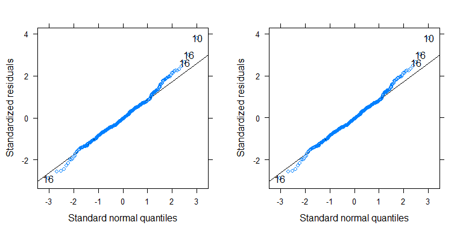

```r
qqp_11 <- qqmath(m_fp_con_11$full_model, id = 0.01, idLabels = as.character(drp_r$P.s))
qqp_12 <- qqmath(m_fp_con_12$full_model, id = 0.01, idLabels = as.character(drp_r$P.s))
grid.arrange(qqp_11, qqp_12, ncol = 2)
```

Again, neither model shows a significant effect of `log_acc`.

```r
nice(m_fp_con_11)
```

```
Mixed Model Anova Table (Type 3 tests, KR-method)

Model: log_con ~ log_acc + (log_acc | P.s) + (Fit | Item)
Data: drp_r
   Effect      df    F p.value
1 log_acc 1, 6.34 0.49     .51
---
Signif. codes:  0 *** 0.001 ** 0.01 * 0.05 + 0.1   1
```

```r
nice(m_fp_con_12)
```

```
Mixed Model Anova Table (Type 3 tests, KR-method)

Model: log_con ~ log_acc + (log_acc || P.s) + (Fit | Item)
Data: drp_r
   Effect        df    F p.value
1 log_acc 1, 250.99 0.67     .42
---
Signif. codes:  0 *** 0.001 ** 0.01 * 0.05 + 0.1   1
```

## With Accepts (log-transformed RTs)

```r
m_fp_con_21 <- mixed(log_con ~ acc_z + (acc_z|P.s) + (Fit| Item), drp_r, progress = FALSE)
```

```
Contrasts set to contr.sum for the following variables: P.s, Fit, Item
```

```r
summary(m_fp_con_21)
```

```
Linear mixed model fit by REML ['merModLmerTest']
Formula: log_con ~ acc_z + (acc_z | P.s) + (Fit | Item)
   Data: drp_r

REML criterion at convergence: 496

Scaled residuals:
    Min      1Q  Median      3Q     Max
-2.8899 -0.5971 -0.0483  0.5693  3.7950

Random effects:
 Groups   Name        Variance  Std.Dev. Corr
 P.s      (Intercept) 0.0702922 0.26513
          acc_z       0.0007547 0.02747  1.00
 Item     (Intercept) 0.0613525 0.24769
          Fit1        0.0021677 0.04656  0.52
 Residual             0.1550257 0.39373
Number of obs: 406, groups:  P.s, 24; Item, 17

Fixed effects:
            Estimate Std. Error t value
(Intercept) -0.18355    0.08169  -2.247
acc_z        0.02415    0.02427   0.995

Correlation of Fixed Effects:
      (Intr)
acc_z 0.161
```

We remove the correlations among the by-participant random effects.

```r
m_fp_con_22 <- mixed(log_con ~ acc_z + (acc_z||P.s) + (Fit|Item), drp_r, expand_re = TRUE, progress = FALSE)
```

```
Contrasts set to contr.sum for the following variables: P.s, Fit, Item
```

```r
summary(m_fp_con_22)
```

```
Linear mixed model fit by REML ['merModLmerTest']
Formula: log_con ~ acc_z + ((1 | P.s) + (0 + re1.acc_z | P.s)) + (1 +      re2.Fit1 | Item)
   Data: drp_r

REML criterion at convergence: 497

Scaled residuals:
    Min      1Q  Median      3Q     Max
-2.7819 -0.5986 -0.0481  0.5553  3.8789

Random effects:
 Groups   Name        Variance Std.Dev. Corr
 P.s      (Intercept) 0.071239 0.26691
 P.s.1    re1.acc_z   0.000000 0.00000
 Item     (Intercept) 0.061995 0.24899
          re2.Fit1    0.002176 0.04665  0.51
 Residual             0.155313 0.39410
Number of obs: 406, groups:  P.s, 24; Item, 17

Fixed effects:
            Estimate Std. Error t value
(Intercept) -0.18611    0.08219  -2.264
acc_z        0.02363    0.02366   0.998

Correlation of Fixed Effects:
      (Intr)
acc_z -0.001
```

We then also remove the by-participant random slopes.

```r
m_fp_con_23 <- mixed(log_con ~ acc_z + (1|P.s) + (Fit|Item), drp_r,
                     expand_re = FALSE, progress = FALSE)
```

```
Contrasts set to contr.sum for the following variables: P.s, Fit, Item
```

```r
summary(m_fp_con_23)
```

```
Linear mixed model fit by REML ['merModLmerTest']
Formula: log_con ~ acc_z + (1 | P.s) + (Fit | Item)
   Data: drp_r

REML criterion at convergence: 497

Scaled residuals:
    Min      1Q  Median      3Q     Max
-2.7819 -0.5986 -0.0481  0.5553  3.8789

Random effects:
 Groups   Name        Variance Std.Dev. Corr
 P.s      (Intercept) 0.071239 0.26691
 Item     (Intercept) 0.061995 0.24899
          Fit1        0.002176 0.04665  0.51
 Residual             0.155313 0.39410
Number of obs: 406, groups:  P.s, 24; Item, 17

Fixed effects:
            Estimate Std. Error t value
(Intercept) -0.18611    0.08219  -2.264
acc_z        0.02363    0.02366   0.998

Correlation of Fixed Effects:
      (Intr)
acc_z -0.001
```

```r
anova(m_fp_con_21, m_fp_con_22, m_fp_con_23)
```

```
Data: drp_r
Models:
m_fp_con_23: log_con ~ acc_z + (1 | P.s) + (Fit | Item)
m_fp_con_22: log_con ~ acc_z + ((1 | P.s) + (0 + re1.acc_z | P.s)) + (1 +
m_fp_con_22:     re2.Fit1 | Item)
m_fp_con_21: log_con ~ acc_z + (acc_z | P.s) + (Fit | Item)
            Df    AIC    BIC  logLik deviance  Chisq Chi Df Pr(>Chisq)
m_fp_con_23  7 511.05 539.09 -248.52   497.05
m_fp_con_22  8 513.05 545.10 -248.52   497.05 0.0000      1     1.0000
m_fp_con_21  9 513.98 550.03 -247.99   495.98 1.0724      1     0.3004
```

There is some difference between the maximal and the final reduced model. However, both models again show the same problematic pattern in their QQ-plots for the same participants.

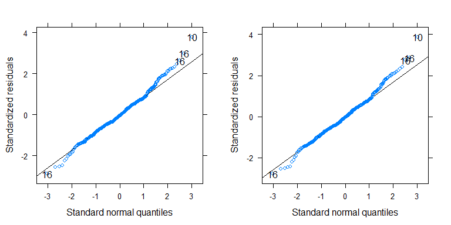

```r
qqp_21 <- qqmath(m_fp_con_21$full_model, id = 0.01, idLabels = as.character(drp_r$P.s))
qqp_22 <- qqmath(m_fp_con_23$full_model, id = 0.01, idLabels = as.character(drp_r$P.s))
grid.arrange(qqp_21, qqp_22, ncol = 2)
```

Furthermore, neither model shows a significant effect of `Accepts` (z-transformed to `acc_z`).

```r
nice(m_fp_con_21)
```

```
Mixed Model Anova Table (Type 3 tests, KR-method)

Model: log_con ~ acc_z + (acc_z | P.s) + (Fit | Item)
Data: drp_r
  Effect      df    F p.value
1  acc_z 1, 8.56 0.71     .42
---
Signif. codes:  0 *** 0.001 ** 0.01 * 0.05 + 0.1   1
```

```r
nice(m_fp_con_23)
```

```
Mixed Model Anova Table (Type 3 tests, KR-method)

Model: log_con ~ acc_z + (1 | P.s) + (Fit | Item)
Data: drp_r
  Effect        df    F p.value
1  acc_z 1, 375.16 0.98     .32
---
Signif. codes:  0 *** 0.001 ** 0.01 * 0.05 + 0.1   1
```

## With Accepts (log-transformed RTs and reduced data set)

```r
m_con_ar_1 <- mixed(log_con ~ acc_z + (acc_z|P.s) + (Fit| Item),
                           drp_r_1, progress = FALSE)
```

```
Contrasts set to contr.sum for the following variables: P.s, Fit, Item
Numerical variables NOT centered on 0 (i.e., interpretation of all main effects might be difficult if in interactions): acc_z
```

```r
summary(m_con_ar_1)
```

```
Linear mixed model fit by REML ['merModLmerTest']
Formula: log_con ~ acc_z + (acc_z | P.s) + (Fit | Item)
   Data: drp_r_1

REML criterion at convergence: 479.2

Scaled residuals:
     Min       1Q   Median       3Q      Max
-2.90444 -0.58465 -0.05651  0.58935  3.00976

Random effects:
 Groups   Name        Variance  Std.Dev. Corr
 P.s      (Intercept) 0.0692489 0.26315
          acc_z       0.0003931 0.01983  1.00
 Item     (Intercept) 0.0629472 0.25089
          Fit1        0.0029309 0.05414  0.50
 Residual             0.1479727 0.38467
Number of obs: 405, groups:  P.s, 24; Item, 17

Fixed effects:
            Estimate Std. Error t value
(Intercept) -0.18363    0.08159  -2.251
acc_z        0.01893    0.02348   0.806

Correlation of Fixed Effects:
      (Intr)
acc_z 0.119
```

We remove the correlations among the random effects.

```r
m_con_ar_2 <- mixed(log_con ~ acc_z + (acc_z||P.s) + (Fit | Item),
                           drp_r_1, progress = FALSE, expand_re = TRUE)
```

```
Contrasts set to contr.sum for the following variables: P.s, Fit, Item
Numerical variables NOT centered on 0 (i.e., interpretation of all main effects might be difficult if in interactions): acc_z
```

```r
summary(m_con_ar_2)
```

```
Linear mixed model fit by REML ['merModLmerTest']
Formula: log_con ~ acc_z + ((1 | P.s) + (0 + re1.acc_z | P.s)) + (1 +      re2.Fit1 | Item)
   Data: drp_r_1

REML criterion at convergence: 479.7

Scaled residuals:
     Min       1Q   Median       3Q      Max
-2.81717 -0.59142 -0.04578  0.56174  2.91999

Random effects:
 Groups   Name        Variance Std.Dev. Corr
 P.s      (Intercept) 0.069950 0.26448
 P.s.1    re1.acc_z   0.000000 0.00000
 Item     (Intercept) 0.063521 0.25203
          re2.Fit1    0.002917 0.05401  0.50
 Residual             0.148079 0.38481
Number of obs: 405, groups:  P.s, 24; Item, 17

Fixed effects:
            Estimate Std. Error t value
(Intercept) -0.18512    0.08197  -2.258
acc_z        0.01791    0.02317   0.773

Correlation of Fixed Effects:
      (Intr)
acc_z -0.001
```

```r
m_con_ar_3 <- mixed(log_con ~ acc_z + (1|P.s) + (Fit | Item),
                           drp_r_1, progress = FALSE, expand_re = FALSE)
```

```
Contrasts set to contr.sum for the following variables: P.s, Fit, Item
Numerical variables NOT centered on 0 (i.e., interpretation of all main effects might be difficult if in interactions): acc_z
```

```r
summary(m_con_ar_3)
```

```
Linear mixed model fit by REML ['merModLmerTest']
Formula: log_con ~ acc_z + (1 | P.s) + (Fit | Item)
   Data: drp_r_1

REML criterion at convergence: 479.7

Scaled residuals:
     Min       1Q   Median       3Q      Max
-2.81717 -0.59142 -0.04578  0.56174  2.91999

Random effects:
 Groups   Name        Variance Std.Dev. Corr
 P.s      (Intercept) 0.069950 0.26448
 Item     (Intercept) 0.063521 0.25203
          Fit1        0.002917 0.05401  0.50
 Residual             0.148079 0.38481
Number of obs: 405, groups:  P.s, 24; Item, 17

Fixed effects:
            Estimate Std. Error t value
(Intercept) -0.18512    0.08197  -2.258
acc_z        0.01791    0.02317   0.773

Correlation of Fixed Effects:
      (Intr)
acc_z -0.001
```

```r
anova(m_con_ar_1, m_con_ar_2, m_con_ar_3)
```

```
Data: drp_r_1
Models:
m_con_ar_3: log_con ~ acc_z + (1 | P.s) + (Fit | Item)
m_con_ar_2: log_con ~ acc_z + ((1 | P.s) + (0 + re1.acc_z | P.s)) + (1 +
m_con_ar_2:     re2.Fit1 | Item)
m_con_ar_1: log_con ~ acc_z + (acc_z | P.s) + (Fit | Item)
           Df    AIC    BIC  logLik deviance  Chisq Chi Df Pr(>Chisq)
m_con_ar_3  7 493.75 521.78 -239.87   479.75
m_con_ar_2  8 495.75 527.78 -239.87   479.75 0.0000      1     1.0000
m_con_ar_1  9 497.20 533.23 -239.60   479.20 0.5504      1     0.4582
```

Despite the correlation estimate of 1/-1, there seems to be some value in it. The QQ-plots show a only mild violations.

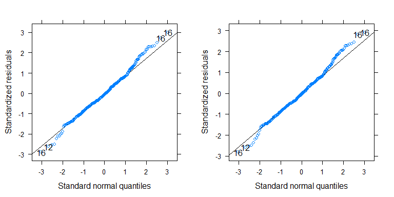

```r
qqp_21 <- qqmath(m_con_ar_1$full_model, id = 0.01, idLabels = as.character(drp_r_1$P.s))
qqp_22 <- qqmath(m_con_ar_3$full_model, id = 0.01, idLabels = as.character(drp_r_1$P.s))
grid.arrange(qqp_21, qqp_22, ncol = 2)
```

Furthermore, neither model shows a significant effect of `Accepts` (z-transformed to `acc_z`).

```r
nice(m_con_ar_1)
```

```
Mixed Model Anova Table (Type 3 tests, KR-method)

Model: log_con ~ acc_z + (acc_z | P.s) + (Fit | Item)
Data: drp_r_1
  Effect      df    F p.value
1  acc_z 1, 8.51 0.47     .51
---
Signif. codes:  0 *** 0.001 ** 0.01 * 0.05 + 0.1   1
```

```r
nice(m_con_ar_3)
```

```
Mixed Model Anova Table (Type 3 tests, KR-method)

Model: log_con ~ acc_z + (1 | P.s) + (Fit | Item)
Data: drp_r_1
  Effect        df    F p.value
1  acc_z 1, 373.68 0.59     .44
---
Signif. codes:  0 *** 0.001 ** 0.01 * 0.05 + 0.1   1
```

# Spillover

## With Fit (log-transformed RTs)

```r
m_fp_spill_f_1 <- mixed(log_spill ~ Fit + (Fit|P.s) + (Fit| Item), drp_r, progress = FALSE)
```

```
Contrasts set to contr.sum for the following variables: Fit, P.s, Item
```

```r
summary(m_fp_spill_f_1)
```

```
Linear mixed model fit by REML ['merModLmerTest']
Formula: log_spill ~ Fit + (Fit | P.s) + (Fit | Item)
   Data: drp_r

REML criterion at convergence: 345.6

Scaled residuals:
    Min      1Q  Median      3Q     Max
-3.2703 -0.5107  0.0394  0.5940  2.8526

Random effects:
 Groups   Name        Variance  Std.Dev. Corr
 P.s      (Intercept) 5.872e-02 0.242331
          Fit1        9.064e-05 0.009520 -1.00
 Item     (Intercept) 4.174e-02 0.204292
          Fit1        1.781e-06 0.001334 1.00
 Residual             1.067e-01 0.326687
Number of obs: 406, groups:  P.s, 24; Item, 17

Fixed effects:
             Estimate Std. Error t value
(Intercept)  0.727997   0.071867  10.130
Fit1        -0.002063   0.016357  -0.126

Correlation of Fixed Effects:
     (Intr)
Fit1 -0.067
```

Due to the large correlation between the by-participants and by-item random-effects parameters we refit the model without the correlations.

```r
m_fp_spill_f_2 <- mixed(log_spill ~ Fit + (Fit||P.s) + (Fit||Item), drp_r, expand_re = TRUE, progress = FALSE)
```

```
Contrasts set to contr.sum for the following variables: Fit, P.s, Item
```

```r
summary(m_fp_spill_f_2)
```

```
Linear mixed model fit by REML ['merModLmerTest']
Formula: log_spill ~ Fit + ((1 | P.s) + (0 + re1.Fit1 | P.s)) + ((1 |
    Item) + (0 + re2.Fit1 | Item))
   Data: drp_r

REML criterion at convergence: 345.9

Scaled residuals:
    Min      1Q  Median      3Q     Max
-3.2435 -0.5028  0.0438  0.5965  2.8763

Random effects:
 Groups   Name        Variance Std.Dev.
 P.s      (Intercept) 0.05874  0.2424
 P.s.1    re1.Fit1    0.00000  0.0000
 Item     (Intercept) 0.04159  0.2039
 Item.1   re2.Fit1    0.00000  0.0000
 Residual             0.10684  0.3269
Number of obs: 406, groups:  P.s, 24; Item, 17

Fixed effects:
             Estimate Std. Error t value
(Intercept)  0.727797   0.071814  10.135
Fit1        -0.002129   0.016246  -0.131

Correlation of Fixed Effects:
     (Intr)
Fit1 0.001
```

Now both random slopes are estimated to be zero, we consequently refit the model without those parameters.

```r
m_fp_spill_f_3 <- mixed(log_spill ~ Fit + (1|P.s) + (1| Item), drp_r, progress = FALSE)
```

```
Contrasts set to contr.sum for the following variables: Fit, P.s, Item
```

```r
summary(m_fp_spill_f_3)
```

```
Linear mixed model fit by REML ['merModLmerTest']
Formula: log_spill ~ Fit + (1 | P.s) + (1 | Item)
   Data: drp_r

REML criterion at convergence: 345.9

Scaled residuals:
    Min      1Q  Median      3Q     Max
-3.2435 -0.5028  0.0438  0.5965  2.8763

Random effects:
 Groups   Name        Variance Std.Dev.
 P.s      (Intercept) 0.05874  0.2424
 Item     (Intercept) 0.04159  0.2039
 Residual             0.10684  0.3269
Number of obs: 406, groups:  P.s, 24; Item, 17

Fixed effects:
             Estimate Std. Error t value
(Intercept)  0.727797   0.071814  10.135
Fit1        -0.002129   0.016246  -0.131

Correlation of Fixed Effects:
     (Intr)
Fit1 0.001
```

Again the final model appears to be the optimal model.

```r
anova(m_fp_spill_f_1, m_fp_spill_f_3)
```

```
Data: drp_r
Models:
m_fp_spill_f_3: log_spill ~ Fit + (1 | P.s) + (1 | Item)
m_fp_spill_f_1: log_spill ~ Fit + (Fit | P.s) + (Fit | Item)
               Df    AIC    BIC  logLik deviance  Chisq Chi Df Pr(>Chisq)
m_fp_spill_f_3  5 355.92 375.95 -172.96   345.92
m_fp_spill_f_1  9 363.62 399.68 -172.81   345.62 0.3005      4     0.9898
```

The QQ-plot again shows a clear deviation from normality for fast responses.

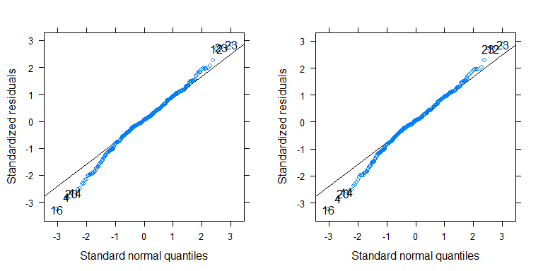

```r
qqp_m1 <- qqmath(m_fp_spill_f_1$full_model, id = 0.01, idLabels = as.character(drp_r$P.s))
qqp_m2 <- qqmath(m_fp_spill_f_3$full_model, id = 0.01, idLabels = as.character(drp_r$P.s))
grid.arrange(qqp_m1, qqp_m2, ncol = 2)
```

The effect of `Fit` is not significant.

```r
nice(m_fp_spill_f_1)
```

```
Mixed Model Anova Table (Type 3 tests, KR-method)

Model: log_spill ~ Fit + (Fit | P.s) + (Fit | Item)
Data: drp_r
  Effect      df    F p.value
1    Fit 1, 8.84 0.02     .90
---
Signif. codes:  0 *** 0.001 ** 0.01 * 0.05 + 0.1   1
```

```r
nice(m_fp_spill_f_3)
```

```
Mixed Model Anova Table (Type 3 tests, KR-method)

Model: log_spill ~ Fit + (1 | P.s) + (1 | Item)
Data: drp_r
  Effect        df    F p.value
1    Fit 1, 365.24 0.02     .90
---
Signif. codes:  0 *** 0.001 ** 0.01 * 0.05 + 0.1   1
```

## With Fit (log-transformed RTs and reduced data set)

We again reduce the data set by one observation with a fast RT for participant 16.

```r
out_spill <- (drp_r$P.s == "16" & drp_r$spillover < 1.0 )
drp_r_r2 <- drp_r[!out_spill,]
drp_r_r2$spilloverw <- as.vector(LambertW::Gaussianize(drp_r_r2$spillover,
                                                        type = "h", method = "MLE"))
```

```r
m_fp_spill_fr_1 <- mixed(log_spill ~ Fit + (Fit|P.s) + (Fit| Item), drp_r_r2, progress = FALSE)
```

```
Contrasts set to contr.sum for the following variables: Fit, P.s, Item
```

```r
summary(m_fp_spill_fr_1)
```

```
Linear mixed model fit by REML ['merModLmerTest']
Formula: log_spill ~ Fit + (Fit | P.s) + (Fit | Item)
   Data: drp_r_r2

REML criterion at convergence: 333.8

Scaled residuals:
     Min       1Q   Median       3Q      Max
-2.81989 -0.51623  0.02662  0.59921  2.88912

Random effects:
 Groups   Name        Variance  Std.Dev. Corr
 P.s      (Intercept) 6.081e-02 0.246595
          Fit1        1.664e-04 0.012899 -1.00
 Item     (Intercept) 4.034e-02 0.200843
          Fit1        2.298e-05 0.004793 1.00
 Residual             1.035e-01 0.321683
Number of obs: 405, groups:  P.s, 24; Item, 17

Fixed effects:
             Estimate Std. Error t value
(Intercept)  0.730974   0.071849  10.174
Fit1        -0.005148   0.016270  -0.316

Correlation of Fixed Effects:
     (Intr)
Fit1 -0.064
```

Due to the large correlation between the by-participants and by-item random-effects parameters we refit the model without the correlations.

```r
m_fp_spill_fr_2 <- mixed(log_spill ~ Fit + (Fit||P.s) + (Fit|| Item), drp_r_r2, progress = FALSE, expand_re = TRUE)
```

```
Contrasts set to contr.sum for the following variables: Fit, P.s, Item
```

```r
summary(m_fp_spill_fr_2)
```

```
Linear mixed model fit by REML ['merModLmerTest']
Formula: log_spill ~ Fit + ((1 | P.s) + (0 + re1.Fit1 | P.s)) + ((1 |
    Item) + (0 + re2.Fit1 | Item))
   Data: drp_r_r2

REML criterion at convergence: 334.5

Scaled residuals:
     Min       1Q   Median       3Q      Max
-2.85675 -0.50674  0.03035  0.58476  2.91524

Random effects:
 Groups   Name        Variance Std.Dev.
 P.s      (Intercept) 0.06083  0.2466
 P.s.1    re1.Fit1    0.00000  0.0000
 Item     (Intercept) 0.04017  0.2004
 Item.1   re2.Fit1    0.00000  0.0000
 Residual             0.10369  0.3220
Number of obs: 405, groups:  P.s, 24; Item, 17

Fixed effects:
             Estimate Std. Error t value
(Intercept)  0.730628   0.071789  10.177
Fit1        -0.005214   0.016030  -0.325

Correlation of Fixed Effects:
     (Intr)
Fit1 0.001
```

Now both random slopes are estimated to be virtually zero, we consequently refit the model without those parameters.

```r
m_fp_spill_fr_3 <- mixed(log_spill ~ Fit + (1|P.s) + (1| Item), drp_r_r2, progress = FALSE)
```

```
Contrasts set to contr.sum for the following variables: Fit, P.s, Item
```

```r
summary(m_fp_spill_fr_3)
```

```
Linear mixed model fit by REML ['merModLmerTest']
Formula: log_spill ~ Fit + (1 | P.s) + (1 | Item)
   Data: drp_r_r2

REML criterion at convergence: 334.5

Scaled residuals:
     Min       1Q   Median       3Q      Max
-2.85675 -0.50674  0.03035  0.58476  2.91524

Random effects:
 Groups   Name        Variance Std.Dev.
 P.s      (Intercept) 0.06083  0.2466
 Item     (Intercept) 0.04017  0.2004
 Residual             0.10369  0.3220
Number of obs: 405, groups:  P.s, 24; Item, 17

Fixed effects:
             Estimate Std. Error t value
(Intercept)  0.730628   0.071789  10.177
Fit1        -0.005214   0.016030  -0.325

Correlation of Fixed Effects:
     (Intr)
Fit1 0.001
```

Again the final model appears to be the optimal model.

```r
anova(m_fp_spill_fr_1, m_fp_spill_fr_2, m_fp_spill_fr_3)
```

[output not shown]

The QQ-plot now only shows comparatively mild violations at the edges.

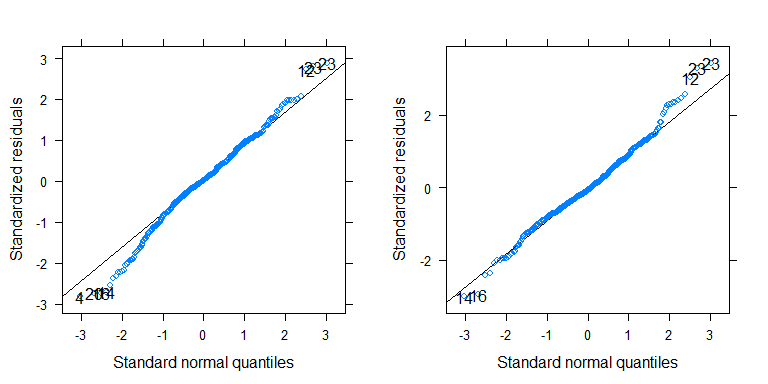

```r
qqp_m1 <- qqmath(m_fp_spill_fr_1$full_model, id = 0.01, idLabels = as.character(drp_r_r2$P.s))
qqp_m2 <- qqmath(m_fp_spill_fr_3$full_model, id = 0.01, idLabels = as.character(drp_r_r2$P.s))
grid.arrange(qqp_m1, qqp_m2, ncol = 2)
```

The effect of `Fit` remains not significant. This would also not change when using the Lambert transform RTs.

```r
nice(m_fp_spill_fr_1)
```

```
Mixed Model Anova Table (Type 3 tests, KR-method)

Model: log_spill ~ Fit + (Fit | P.s) + (Fit | Item)
Data: drp_r_r2
  Effect      df    F p.value
1    Fit 1, 9.01 0.10     .76
---
Signif. codes:  0 *** 0.001 ** 0.01 * 0.05 + 0.1   1
```

```r
nice(m_fp_spill_fr_3)
```

[output not shown]

## With Accepts (log-transformed RTs and Accepts)

```r
m_fp_spill_al_1 <- mixed(log_spill ~ log_acc + (log_acc|P.s) + (Fit| Item),
                         drp_r, progress = FALSE)
```

```
Contrasts set to contr.sum for the following variables: P.s, Fit, Item
Numerical variables NOT centered on 0 (i.e., interpretation of all main effects might be difficult if in interactions): log_acc
```

```r
summary(m_fp_spill_al_1)
```

```
Linear mixed model fit by REML ['merModLmerTest']
Formula: log_spill ~ log_acc + (log_acc | P.s) + (Fit | Item)
   Data: drp_r

REML criterion at convergence: 339.1

Scaled residuals:
    Min      1Q  Median      3Q     Max
-3.3848 -0.4801  0.0475  0.5659  2.9241

Random effects:
 Groups   Name        Variance  Std.Dev.  Corr
 P.s      (Intercept) 3.689e-01 0.6073549
          log_acc     1.457e-01 0.3816828 -0.92
 Item     (Intercept) 4.199e-02 0.2049254
          Fit1        5.557e-07 0.0007454 -1.00
 Residual             1.041e-01 0.3226204
Number of obs: 406, groups:  P.s, 24; Item, 17

Fixed effects:
            Estimate Std. Error t value
(Intercept)  0.83253    0.24530   3.394
log_acc     -0.06832    0.15679  -0.436

Correlation of Fixed Effects:
        (Intr)
log_acc -0.956
```

This model has correlations at the boundary of the parameter space. We refit the model without the correlations.

```r
m_fp_spill_al_2 <- mixed(log_spill ~ log_acc + (log_acc||P.s) + (Fit|| Item),
                         drp_r, progress = FALSE, expand_re = TRUE)
```

```
Contrasts set to contr.sum for the following variables: P.s, Fit, Item
Numerical variables NOT centered on 0 (i.e., interpretation of all main effects might be difficult if in interactions): log_acc
```

```r
summary(m_fp_spill_al_2)
```

```
Linear mixed model fit by REML ['merModLmerTest']
Formula: log_spill ~ log_acc + ((1 | P.s) + (0 + re1.log_acc | P.s)) +
    ((1 | Item) + (0 + re2.Fit1 | Item))
   Data: drp_r

REML criterion at convergence: 341

Scaled residuals:
    Min      1Q  Median      3Q     Max
-3.3218 -0.5263  0.0251  0.5856  2.8998

Random effects:
 Groups   Name        Variance Std.Dev.
 P.s      (Intercept) 0.055690 0.23599
 P.s.1    re1.log_acc 0.001424 0.03774
 Item     (Intercept) 0.041693 0.20419
 Item.1   re2.Fit1    0.000000 0.00000
 Residual             0.106511 0.32636
Number of obs: 406, groups:  P.s, 24; Item, 17

Fixed effects:
            Estimate Std. Error t value
(Intercept)   0.9010     0.1918   4.699
log_acc      -0.1152     0.1187  -0.970

Correlation of Fixed Effects:
        (Intr)
log_acc -0.927
```

The by-item random slope is zero hence we refit the model without it.

```r
m_fp_spill_al_3 <- mixed(log_spill ~ log_acc + (log_acc||P.s) + (1| Item),
                         drp_r, progress = FALSE, expand_re = TRUE)
```

```
Contrasts set to contr.sum for the following variables: P.s, Item
Numerical variables NOT centered on 0 (i.e., interpretation of all main effects might be difficult if in interactions): log_acc
```

```r
summary(m_fp_spill_al_3)
```

```
Linear mixed model fit by REML ['merModLmerTest']
Formula: log_spill ~ log_acc + ((1 | P.s) + (0 + re1.log_acc | P.s)) +      (1 | Item)
   Data: drp_r

REML criterion at convergence: 341

Scaled residuals:
    Min      1Q  Median      3Q     Max
-3.3218 -0.5263  0.0251  0.5856  2.8998

Random effects:
 Groups   Name        Variance Std.Dev.
 P.s      (Intercept) 0.055690 0.23599
 P.s.1    re1.log_acc 0.001424 0.03774
 Item     (Intercept) 0.041693 0.20419
 Residual             0.106511 0.32636
Number of obs: 406, groups:  P.s, 24; Item, 17

Fixed effects:
            Estimate Std. Error t value
(Intercept)   0.9010     0.1918   4.699
log_acc      -0.1152     0.1187  -0.970

Correlation of Fixed Effects:
        (Intr)
log_acc -0.927
```

Finally, because the correlation for the by-participant random effects was not 1 or -1 we finally add them again to the reduced model of the previous step.

```r
m_fp_spill_al_4 <- mixed(log_spill ~ log_acc + (log_acc|P.s) + (1| Item),
                         drp_r, progress = FALSE, expand_re = TRUE)
```

```
Contrasts set to contr.sum for the following variables: P.s, Item
Numerical variables NOT centered on 0 (i.e., interpretation of all main effects might be difficult if in interactions): log_acc
```

```r
summary(m_fp_spill_al_4)
```

```
Linear mixed model fit by REML ['merModLmerTest']
Formula: log_spill ~ log_acc + (1 + re1.log_acc | P.s) + (1 | Item)
   Data: drp_r

REML criterion at convergence: 339.1

Scaled residuals:
    Min      1Q  Median      3Q     Max
-3.3881 -0.4807  0.0469  0.5664  2.9253

Random effects:
 Groups   Name        Variance Std.Dev. Corr
 P.s      (Intercept) 0.36798  0.6066
          re1.log_acc 0.14535  0.3813   -0.92
 Item     (Intercept) 0.04199  0.2049
 Residual             0.10409  0.3226
Number of obs: 406, groups:  P.s, 24; Item, 17

Fixed effects:
            Estimate Std. Error t value
(Intercept)  0.83231    0.24520   3.394
log_acc     -0.06814    0.15673  -0.435

Correlation of Fixed Effects:
        (Intr)
log_acc -0.956
```

Overall the best model appears to be the most reduced model 3.

```r
anova(m_fp_spill_al_1,m_fp_spill_al_2, m_fp_spill_al_3, m_fp_spill_al_4)
```

```
Data: drp_r
Models:
m_fp_spill_al_3: log_spill ~ log_acc + ((1 | P.s) + (0 + re1.log_acc | P.s)) +
m_fp_spill_al_3:     (1 | Item)
m_fp_spill_al_2: log_spill ~ log_acc + ((1 | P.s) + (0 + re1.log_acc | P.s)) +
m_fp_spill_al_2:     ((1 | Item) + (0 + re2.Fit1 | Item))
m_fp_spill_al_4: log_spill ~ log_acc + (1 + re1.log_acc | P.s) + (1 | Item)
m_fp_spill_al_1: log_spill ~ log_acc + (log_acc | P.s) + (Fit | Item)
                Df    AIC    BIC  logLik deviance  Chisq Chi Df Pr(>Chisq)
m_fp_spill_al_3  6 353.01 377.05 -170.50   341.01
m_fp_spill_al_2  7 355.01 383.05 -170.50   341.01 0.0000      1      1.000
m_fp_spill_al_4  7 353.13 381.18 -169.57   339.13 1.8767      0     <2e-16 ***
m_fp_spill_al_1  9 357.13 393.19 -169.56   339.13 0.0019      2      0.999
---
Signif. codes:  0 *** 0.001 ** 0.01 * 0.05 . 0.1   1
```

The QQ-plot of both models again shows some departure from normality for small and large RTs.

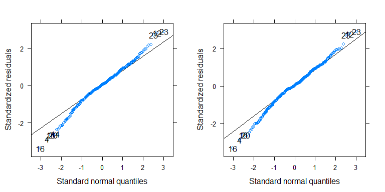

```r
qqp_m1 <- qqmath(m_fp_spill_al_1$full_model, id = 0.01, idLabels = as.character(drp_r$P.s))
qqp_m2 <- qqmath(m_fp_spill_al_3$full_model, id = 0.01, idLabels = as.character(drp_r$P.s))
grid.arrange(qqp_m1, qqp_m2, ncol = 2)
```

The effect of `log_acc` is not significant.

```r
nice(m_fp_spill_al_1)
```

```
Mixed Model Anova Table (Type 3 tests, KR-method)

Model: log_spill ~ log_acc + (log_acc | P.s) + (Fit | Item)
Data: drp_r
   Effect       df    F p.value
1 log_acc 1, 13.48 0.17     .69
---
Signif. codes:  0 *** 0.001 ** 0.01 * 0.05 + 0.1   1
```

```r
nice(m_fp_spill_al_3)
```

```
Mixed Model Anova Table (Type 3 tests, KR-method)

Model: log_spill ~ log_acc + (log_acc || P.s) + (1 | Item)
Data: drp_r
   Effect        df    F p.value
1 log_acc 1, 131.95 0.83     .36
---
Signif. codes:  0 *** 0.001 ** 0.01 * 0.05 + 0.1   1
```

### With Accepts (log-transformed RTs)

```r
m_fp_spill_a_1 <- mixed(log_spill ~ acc_z + (acc_z|P.s) + (Fit| Item), drp_r, progress = FALSE)
```

```
Contrasts set to contr.sum for the following variables: P.s, Fit, Item
```

```r
summary(m_fp_spill_a_1)
```

```
Linear mixed model fit by REML ['merModLmerTest']
Formula: log_spill ~ acc_z + (acc_z | P.s) + (Fit | Item)
   Data: drp_r

REML criterion at convergence: 343.2

Scaled residuals:
    Min      1Q  Median      3Q     Max
-3.3750 -0.4771  0.0427  0.5703  2.9231

Random effects:
 Groups   Name        Variance  Std.Dev.  Corr
 P.s      (Intercept) 5.869e-02 0.2422661
          acc_z       3.250e-03 0.0570096 -0.01
 Item     (Intercept) 4.199e-02 0.2049258
          Fit1        8.061e-08 0.0002839 -1.00
 Residual             1.044e-01 0.3231616
Number of obs: 406, groups:  P.s, 24; Item, 17

Fixed effects:
            Estimate Std. Error t value
(Intercept)  0.72895    0.07216  10.101
acc_z       -0.01333    0.02486  -0.536

Correlation of Fixed Effects:
      (Intr)
acc_z -0.001
```

Again we observe one large correlation between the by-item random-effects parameters and we refit the model without this correlation. We also remove the other correlation as it is virtually zero.

```r
m_fp_spill_a_2 <- mixed(log_spill ~ acc_z + (acc_z||P.s) + (Fit||Item), drp_r, expand_re = TRUE, progress = FALSE)
```

```
Contrasts set to contr.sum for the following variables: P.s, Fit, Item
```

```r
summary(m_fp_spill_a_2)
```

```
Linear mixed model fit by REML ['merModLmerTest']
Formula: log_spill ~ acc_z + ((1 | P.s) + (0 + re1.acc_z | P.s)) + ((1 |
    Item) + (0 + re2.Fit1 | Item))
   Data: drp_r

REML criterion at convergence: 343.2

Scaled residuals:
    Min      1Q  Median      3Q     Max
-3.3754 -0.4753  0.0425  0.5699  2.9236

Random effects:
 Groups   Name        Variance Std.Dev.
 P.s      (Intercept) 0.058667 0.24221
 P.s.1    re1.acc_z   0.003265 0.05714
 Item     (Intercept) 0.041990 0.20491
 Item.1   re2.Fit1    0.000000 0.00000
 Residual             0.104430 0.32316
Number of obs: 406, groups:  P.s, 24; Item, 17

Fixed effects:
            Estimate Std. Error t value
(Intercept)  0.72897    0.07215  10.103
acc_z       -0.01326    0.02488  -0.533

Correlation of Fixed Effects:
      (Intr)
acc_z 0.003
```

And the by-item random slope is now estimated at zero, we consequently refit the model without this parameters.

```r
m_fp_spill_a_3 <- mixed(log_spill ~ acc_z + (acc_z||P.s) + (1| Item), drp_r, expand_re = TRUE, progress = FALSE)
```

```
Contrasts set to contr.sum for the following variables: P.s, Item
```

```r
summary(m_fp_spill_a_3)
```

```
Linear mixed model fit by REML ['merModLmerTest']
Formula: log_spill ~ acc_z + ((1 | P.s) + (0 + re1.acc_z | P.s)) + (1 |      Item)
   Data: drp_r

REML criterion at convergence: 343.2

Scaled residuals:
    Min      1Q  Median      3Q     Max
-3.3754 -0.4753  0.0425  0.5699  2.9236

Random effects:
 Groups   Name        Variance Std.Dev.
 P.s      (Intercept) 0.058667 0.24221
 P.s.1    re1.acc_z   0.003265 0.05714
 Item     (Intercept) 0.041990 0.20491
 Residual             0.104430 0.32316
Number of obs: 406, groups:  P.s, 24; Item, 17

Fixed effects:
            Estimate Std. Error t value
(Intercept)  0.72897    0.07215  10.103
acc_z       -0.01326    0.02488  -0.533

Correlation of Fixed Effects:
      (Intr)
acc_z 0.003
```

This model seems reasonable and only provides basically the same account as the first model.

```r
anova(m_fp_spill_a_1, m_fp_spill_a_3)
```

```
Data: drp_r
Models:
m_fp_spill_a_3: log_spill ~ acc_z + ((1 | P.s) + (0 + re1.acc_z | P.s)) + (1 |
m_fp_spill_a_3:     Item)
m_fp_spill_a_1: log_spill ~ acc_z + (acc_z | P.s) + (Fit | Item)
               Df    AIC    BIC  logLik deviance Chisq Chi Df Pr(>Chisq)
m_fp_spill_a_3  6 355.18 379.22 -171.59   343.18
m_fp_spill_a_1  9 361.18 397.23 -171.59   343.18 7e-04      3          1
```

The QQ-plot of both models again shows considerable departarue from normality for small RTs.

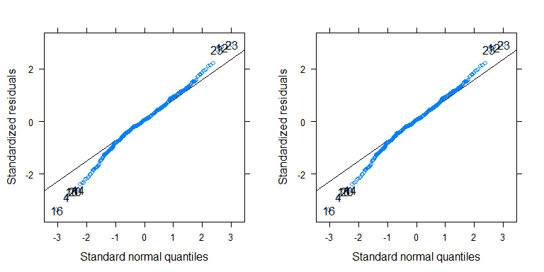

```r
qqp_m1 <- qqmath(m_fp_spill_a_1$full_model, id = 0.01, idLabels = as.character(drp_r$P.s))
qqp_m2 <- qqmath(m_fp_spill_a_3$full_model, id = 0.01, idLabels = as.character(drp_r$P.s))
grid.arrange(qqp_m1, qqp_m2, ncol = 2)
```

The effect of `acc_z` is not significant.

```r
nice(m_fp_spill_a_1)
```

```
Mixed Model Anova Table (Type 3 tests, KR-method)

Model: log_spill ~ acc_z + (acc_z | P.s) + (Fit | Item)
Data: drp_r
  Effect       df    F p.value
1  acc_z 1, 13.20 0.25     .62
---
Signif. codes:  0 *** 0.001 ** 0.01 * 0.05 + 0.1   1
```

```r
nice(m_fp_spill_a_3)
```

```
Mixed Model Anova Table (Type 3 tests, KR-method)

Model: log_spill ~ acc_z + (acc_z || P.s) + (1 | Item)
Data: drp_r
  Effect       df    F p.value
1  acc_z 1, 13.22 0.26     .62
---
Signif. codes:  0 *** 0.001 ** 0.01 * 0.05 + 0.1   1
```

## With Accept (reduced data set)

Finally we again use the reduced data set.

```r
m_fp_spill_lambert_a_1 <- mixed(log_spill ~ acc_z + (acc_z|P.s) + (Fit| Item), drp_r_r2, progress = FALSE)
```

```
Contrasts set to contr.sum for the following variables: P.s, Fit, Item
Numerical variables NOT centered on 0 (i.e., interpretation of all main effects might be difficult if in interactions): acc_z
```

```r
summary(m_fp_spill_lambert_a_1)
```

```
Linear mixed model fit by REML ['merModLmerTest']
Formula: log_spill ~ acc_z + (acc_z | P.s) + (Fit | Item)
   Data: drp_r_r2

REML criterion at convergence: 330.3

Scaled residuals:
     Min       1Q   Median       3Q      Max
-3.03130 -0.50190  0.03919  0.58498  2.99469

Random effects:
 Groups   Name        Variance  Std.Dev. Corr
 P.s      (Intercept) 6.019e-02 0.24533
          acc_z       3.689e-03 0.06074  -0.09
 Item     (Intercept) 4.052e-02 0.20129
          Fit1        1.616e-05 0.00402  1.00
 Residual             1.008e-01 0.31752
Number of obs: 405, groups:  P.s, 24; Item, 17

Fixed effects:
            Estimate Std. Error t value
(Intercept)  0.73206    0.07188  10.184
acc_z       -0.01611    0.02516  -0.641

Correlation of Fixed Effects:
      (Intr)
acc_z -0.030
```

We again remove the correlations.

```r
m_fp_spill_lambert_a_2 <- mixed(log_spill ~ acc_z + (acc_z||P.s) + (Fit || Item), drp_r_r2, progress = FALSE, expand_re = TRUE)
```

```
Contrasts set to contr.sum for the following variables: P.s, Fit, Item
Numerical variables NOT centered on 0 (i.e., interpretation of all main effects might be difficult if in interactions): acc_z
```

```r
summary(m_fp_spill_lambert_a_2)
```

```
Linear mixed model fit by REML ['merModLmerTest']
Formula: log_spill ~ acc_z + ((1 | P.s) + (0 + re1.acc_z | P.s)) + ((1 |
    Item) + (0 + re2.Fit1 | Item))
   Data: drp_r_r2

REML criterion at convergence: 330.4

Scaled residuals:
     Min       1Q   Median       3Q      Max
-3.00810 -0.49013  0.02915  0.58609  2.98748

Random effects:
 Groups   Name        Variance Std.Dev.
 P.s      (Intercept) 0.060053 0.24506
 P.s.1    re1.acc_z   0.003891 0.06237
 Item     (Intercept) 0.040504 0.20126
 Item.1   re2.Fit1    0.000000 0.00000
 Residual             0.100774 0.31745
Number of obs: 405, groups:  P.s, 24; Item, 17

Fixed effects:
            Estimate Std. Error t value
(Intercept)  0.73118    0.07192  10.166
acc_z       -0.01575    0.02544  -0.619

Correlation of Fixed Effects:
      (Intr)
acc_z 0.003
```

Now the by-item random slope is estimated to be virtually zero, we consequently refit the model without this parameter.

```r
m_fp_spill_lambert_a_3 <- mixed(log_spill ~ acc_z + (acc_z||P.s) + (1| Item), drp_r_r2, progress = FALSE, expand_re = TRUE)
```

```
Contrasts set to contr.sum for the following variables: P.s, Item
Numerical variables NOT centered on 0 (i.e., interpretation of all main effects might be difficult if in interactions): acc_z
```

```r
summary(m_fp_spill_lambert_a_3)
```

```
Linear mixed model fit by REML ['merModLmerTest']
Formula: log_spill ~ acc_z + ((1 | P.s) + (0 + re1.acc_z | P.s)) + (1 |      Item)
   Data: drp_r_r2

REML criterion at convergence: 330.4

Scaled residuals:
     Min       1Q   Median       3Q      Max
-3.00810 -0.49013  0.02915  0.58609  2.98748

Random effects:
 Groups   Name        Variance Std.Dev.
 P.s      (Intercept) 0.060053 0.24506
 P.s.1    re1.acc_z   0.003891 0.06237
 Item     (Intercept) 0.040504 0.20126
 Residual             0.100774 0.31745
Number of obs: 405, groups:  P.s, 24; Item, 17

Fixed effects:
            Estimate Std. Error t value
(Intercept)  0.73118    0.07192  10.166
acc_z       -0.01575    0.02544  -0.619

Correlation of Fixed Effects:
      (Intr)
acc_z 0.003
```

Again the final model appears to be the optimal model.

```r
anova(m_fp_spill_lambert_a_1, m_fp_spill_lambert_a_2, m_fp_spill_lambert_a_3)
```

```
Data: drp_r_r2
Models:
m_fp_spill_lambert_a_3: log_spill ~ acc_z + ((1 | P.s) + (0 + re1.acc_z | P.s)) + (1 |
m_fp_spill_lambert_a_3:     Item)
m_fp_spill_lambert_a_2: log_spill ~ acc_z + ((1 | P.s) + (0 + re1.acc_z | P.s)) + ((1 |
m_fp_spill_lambert_a_2:     Item) + (0 + re2.Fit1 | Item))
m_fp_spill_lambert_a_1: log_spill ~ acc_z + (acc_z | P.s) + (Fit | Item)
                       Df    AIC    BIC  logLik deviance  Chisq Chi Df Pr(>Chisq)
m_fp_spill_lambert_a_3  6 342.41 366.43 -165.20   330.41
m_fp_spill_lambert_a_2  7 344.41 372.43 -165.20   330.41 0.0000      1     1.0000
m_fp_spill_lambert_a_1  9 348.32 384.35 -165.16   330.32 0.0887      2     0.9566
```

The QQ-plot now still shows violations at the edges.

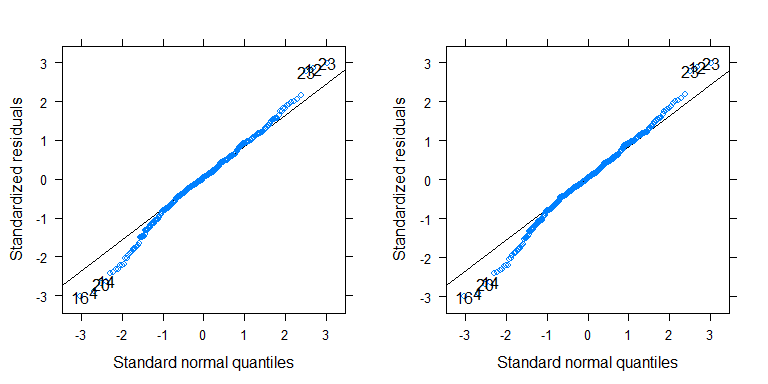

```r
qqp_m1 <- qqmath(m_fp_spill_lambert_a_1$full_model, id = 0.01, idLabels = as.character(drp_r_r2$P.s))
qqp_m2 <- qqmath(m_fp_spill_lambert_a_3$full_model, id = 0.01, idLabels = as.character(drp_r_r2$P.s))
grid.arrange(qqp_m1, qqp_m2, ncol = 2)
```

```r
nice(m_fp_spill_lambert_a_1)
```

```
Mixed Model Anova Table (Type 3 tests, KR-method)

Model: log_spill ~ acc_z + (acc_z | P.s) + (Fit | Item)
Data: drp_r_r2
  Effect       df    F p.value
1  acc_z 1, 13.63 0.37     .55
---
Signif. codes:  0 *** 0.001 ** 0.01 * 0.05 + 0.1   1
```

```r
nice(m_fp_spill_lambert_a_3)
```

```
Mixed Model Anova Table (Type 3 tests, KR-method)

Model: log_spill ~ acc_z + (acc_z || P.s) + (1 | Item)
Data: drp_r_r2
  Effect       df    F p.value
1  acc_z 1, 13.74 0.36     .56
---
Signif. codes:  0 *** 0.001 ** 0.01 * 0.05 + 0.1   1
```